# 统计机器学习 Homework 04

雍崔扬 21307140051

2025-02-15

## Problem 1

设输入向量 $X$ 有 $n$ 个特征 $X^{(1)},\dots,X^{(n)}$，因变量 $Y$ 有 $K$ 个类别: $c_1,\dots,c_K$  
第 $j=1,\dots,n$ 个特征 $X^{(j)}$ 有 $S_j$ 个可能取值: $a_{j,1},\dots,a_{j,S_j}$

用极大似然估计法推出朴素 Bayes 中的先验概率 $\text{P}\{Y=c_k\}$ 和条件概率 $\text{P}\{X^{(j)}=x^{(j)}|Y=c_k\}$ 的极大似然估计.  
即证明:

- ① 先验概率 $\text{P}\{Y=c_k\}$ 的极大似然估计为:
  $$\text{P}\{Y=c_k\} = \frac{1}{N} \sum_{i=1}^N I(y_i = c_k)\ (k=1,\dots,K)$$
- ② 条件概率 $\text{P}\{X^{(j)}=x^{(j)}|Y=c_k\}$ 的极大似然估计为:
  $$\text{P}\{X^{(j)}=a_{j,l}|Y=c_k\} = \frac{\sum_{i=1}^N
  I(x_i^{(j)}=a_{j,l},y_i = c_k)}{\sum_{i=1}^N I(y_i=c_k)}\text{ where }
  \begin{cases}
  j = 1,2,\dots,n\\
  l=1,2,\dots, S_j\\
  k=1,2,\dots,K
  \end{cases}$$

**Defination:**

- $k$ 维类别分布 (Categorical Distribution) $M_k(1,\pi)$ 设事件 $E_1,\dots,E_k$ 为样本空间 $\Omega$ 的一个分割，即满足 $\begin{cases} E_i\cap E_j = \emptyset,&\forall\ i\neq j\\ \underset{i=1}{\overset{k}{\bigcup}} E_i = \Omega\end{cases}$  
  对任意 $i=1,\dots,k$ 记 $\begin{cases} \xi_i = {\large\mathbb 1}_{E_i} \\ \pi_i = \text{P}\{E_i\} = \text{P}\{\xi_i=1\} \end{cases}$ 并记 $k$ 维向量 $\begin{cases} \xi = (\xi_1,\dots,\xi_k)\\ \pi = (\pi_1,\dots,\pi_k)\end{cases}$  
  我们称随机向量 $\xi$ 服从为 $k$ 维类别分布，记为 $M_k(1,\pi)$  
  满足 $\begin{cases} \text{P}\{\xi = e_1\} = \text{P}\{\xi_1=1\} = \pi_1\\ \qquad\vdots\\ \text{P}\{\xi = e_k\} = \text{P}\{\xi_k=1\} = \pi_k\end{cases}$ (其中 $e_1,\dots,e_k$ 为 $\mathbb R^k$ 的标准单位基向量)  
  它可以视为 Bernoulli 分布 (只有 $0,1$ 两个类别) 推广到 $k$ 个类别的情况，  
  每次试验结果只能是 $k$ 个类别中的一个.

  容易验证 $\xi \sim M_k(1,\pi)$ 的**均值向量**和**协方差矩阵**为：
  $$\begin{cases}
  \text{E}[\xi] = \pi = (\pi_1,\dots,\pi_k)\\
  \text{Cov}[\xi] = \text{diag}(\pi) - \pi\pi^{\mathrm T} =
  \begin{bmatrix}
  \pi_1(1-\pi_1) & -\pi_1\pi_2 &\dots &-\pi_1\pi_k\\
  -\pi_2\pi_1 & \pi_2(1-\pi_2) &\dots &-\pi_2\pi_k\\
  \vdots & \vdots &\ddots &\vdots\\
  -\pi_k\pi_1 & -\pi_k\pi_2 &\dots &
  \pi_k(1-\pi_k)\end{bmatrix}\end{cases}$$
- 多项分布 (Multinomial Distribution) $M_k(n,\pi)$
  多项分布，即 $n$ 个独立同分布的 $k$ 维类别随机变量之和的分布.
  记 $X=(X_1,\dots,X_n) \in \mathbb R^{k\times n}$ 为取自 $k$ 维类比分布 $M_k(1,\pi)$ 的简单随机样本，样本量为 $n$
  则 $Y = 1_n^{\mathrm T}X^{\mathrm T} = \underset{i=1}{\overset{n}\sum}X_i^{\mathrm T} = (\underset{i=1}{\overset{n}\sum} X_{1i},\dots,\underset{i=1}{\overset{n}\sum}X_{ki})^{\mathrm T}\sim M_k(n,\pi)$
  (其中分量 $Y_j = \underset{i=1}{\overset{n}\sum}X_{ji}$ 表示样本 $X$ 中事件 $E_j$ 发生的频数)
  满足 $\text{P}\{Y_{1} = n_1,\dots,Y_k=n_k\} = \frac{n!}{n_1!\dotsm n_k!}\pi_1^{n_1}\dots \pi_k^{n_k}$, 其中 $\begin{cases} n_i\geq 0,\quad(\forall\ i=1,\dots,k)\\ \underset{i=1}{\overset{n}\sum}n_i = n\end{cases}$
  容易验证 $Y \sim M_k(n,\pi)$ 的**均值向量**和**协方差矩阵**为：
  $$\begin{cases}
  \text{E}[Y] = n\pi = n(\pi_1,\dots,\pi_k)\\
  \text{Cov}[Y] = n[\text{diag}(\pi) - \pi\pi^{\mathrm T}] =
  n\begin{bmatrix}
  \pi_1(1-\pi_1) & -\pi_1\pi_2 &\dots &-\pi_1\pi_k\\
  -\pi_2\pi_1 & \pi_2(1-\pi_2) &\dots &-\pi_2\pi_k\\
  \vdots & \vdots &\ddots &\vdots\\
  -\pi_k\pi_1 & -\pi_k\pi_2 &\dots &
  \pi_k(1-\pi_k)\end{bmatrix}\end{cases}$$

**Lemma:**
给定样本 $X=(X_1,\dots,X_n) \in \mathbb R^{k\times n}$
则多项分布随机变量 $Y=1_n^{\mathrm T}X^{\mathrm T} \sim M_k(n,\pi)$ 的参数向量 $\pi$ 的极大似然估计量 $\hat \pi$ 为:
$$\hat \pi := [\frac{n_1}{n},\dots, \frac{n_k}{n}]$$
其中 $n_i\geq 0$ 是样本 $X$ 中类别 $i$ 出现的频数，满足 $\sum_{i=1}^k n_i = n$

- **Proof:**
  似然函数为:
  $$\begin{align}
  L(\pi|X)
  &= \text{P}\{Y_1= n_1,\dots, Y_k = n_k\}\\
  &= \frac{n!}{n_1!\dotsm n_k!}\pi_1^{n_1}\dots \pi_k^{n_k}
  \end{align}$$
  对数似然函数为:
  $$\begin{align}
  \log L(\pi|X)
  &= \log(\frac{n!}{n_1!\dotsm n_k!}\pi_1^{n_1}\dots \pi_k^{n_k})\\
  &= \log(n!) - \sum_{i=1}^k \log(n_i!) + \sum_{i=1}^k n_i \log(\pi_i)
  \end{align}$$
  考虑求解关于 $\pi$ 的最大化问题:
  $$\max_\pi \{\log L(\pi | X): \begin{cases}
  1_k^{\mathrm T}\pi = 1\\
  \pi \succeq 0_k\end{cases}\}$$
  显然这是一个凸优化问题，最大值点即为 KKT 点.
  定义 Lagrange 函数为:
  $$\begin{align}
  \mathcal L(\pi, \lambda)
  &=
  \log L(\pi|X) - \lambda (1_k^{\mathrm T}\pi - 1)\\
  &=
  \log(n!) - \sum_{i=1}^k \log(n_i!) + \sum_{i=1}^k n_i \log(\pi_i) -
  \lambda \sum_{i=1}^k \pi_i + \lambda
  \end{align}$$
  则 KKT 条件为:
  $$\begin{cases}
  \frac{\partial }{\partial \pi_i} \mathcal L (\pi,\lambda) =
  \frac{n_i}{\pi} - \lambda = 0 & (i=1,\dots,k)\\
  \sum_{i=1}^k \pi_i = 1\\
  \pi_i \geq 0 & (i=1,\dots,k)
  \end{cases}$$
  解得:
  $$\begin{cases}
  \lambda = \frac1n\\
  \pi_i = \frac{n_i}{n}\ (i=1,\dots,k)
  \end{cases}$$
  因此参数向量 $\pi$ 的极大似然估计量 $\hat \pi$ 为:
  $$\hat \pi := [\frac{n_1}{n},\dots, \frac{n_k}{n}]$$
  引理得证.

**Proof:**  
根据引理很容易得到以下结论:

- ① 先验概率 $\text{P}\{Y=c_k\}$ 的极大似然估计为:
  $$\begin{align}
  \text{P}\{Y=c_k\}
  &= \frac{\text{Number of samples with }Y=c_k}{\text{Total
  number of samples}}\\
  &= \frac{1}{N} \sum_{i=1}^N I(y_i = c_k)\\
  \end{align}(k=1,\dots,K)$$
- ② 条件概率 $\text{P}\{X^{(j)}=x^{(j)}|Y=c_k\}$ 的极大似然估计为:
  $$\begin{align}
  &\text{P}\{X^{(j)}=a_{j,l}|Y=c_k\} \\
  &= \frac{\text{P}\{X^{(j)}=a_{j,l},Y=c_k\}}{\text{P}\{Y=c_k\}}\\
  &= \left(\frac{\text{Number of samples with }Y=c_k}{\text{Total
  number of samples}}\right) / \left(\frac{\text{Number of samples with
  }Y=c_k}{\text{Total number of samples}}\right)\\
  &= (\frac{1}{N}\sum_{i=1}^N I(x_i^{(j)}=a_{j,l},y_i = c_k)) /
  (\frac{1}{N}\sum_{i=1}^N I(y_i=c_k))\\
  &= \frac{\sum_{i=1}^N I(x_i^{(j)}=a_{j,l},y_i = c_k)}{\sum_{i=1}^N
  I(y_i=c_k)}\\
  \end{align} \text{ where }\begin{cases}j = 1,2,\dots,n\\l=1,2,\dots,
  S_j\\k=1,2,\dots,K\end{cases}$$

命题得证.

## Problem 2

使用训练数据学习 Bayes 分类器.  
分别采用极大似然估计和 Bayes 估计 $(\lambda = 1)$， 写出给定输入 $x=(2,M)^{\mathrm T}$ 时的类标记.

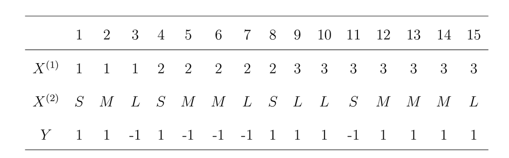

**Solution:**

- **① 极大似然估计:**
  先验概率:
  $$\text{P}\{Y=1\} = \frac{10}{15} = \frac{2}{3}\\
  \text{P}\{Y=-1\} = \frac{5}{15} = \frac{1}{3}\\
  \text{P}\{X^{(1)}=2,X^{(2)}=M\} = \frac{2}{15}$$
  条件概率:
  $$\text{P}\{X^{(1)} = 2|Y=1\} = \frac{2}{10} = \frac{1}{5}\\
  \text{P}\{X^{(2)} = M|Y=1\} = \frac{4}{10} = \frac{2}{5}\\
  \text{P}\{X^{(1)} = 2|Y=-1\} = \frac{3}{5}\\
  \text{P}\{X^{(2)} = M|Y=-1\} = \frac{2}{5}$$
  于是条件概率 $P(Y = y | X^{(1)} = 2, X^{(2)} = M)$ 的极大似然估计为:
  $$
  $$\begin{align}
  \text{P}(Y = 1 | X^{(1)} = 2, X^{(2)} = M)
  &= \frac{\text{P}\{Y=1\} \text{P}\{X^{(1)}=2|Y=1\}
  \text{P}\{X^{(2)}=M|Y=1\}}{\text{P}\{X^{(1)}=2,X^{(2)}=M\}}\\
  &=
  \frac{\frac{2}{3} \cdot \frac{1}{5} \cdot \frac{2}{5}}{\frac2{15}}\\
  &=
  \frac{2}{5}\\
  \hline
  \text{P}(Y = -1 | X^{(1)} = 2, X^{(2)} = M)
  &= \frac{\text{P}\{Y=-1\} \text{P}\{X^{(1)}=2|Y=-1\}
  \text{P}\{X^{(2)}=M|Y=-1\}}{\text{P}\{X^{(1)}=2,X^{(2)}=M\}}\\
  &=
  \frac{\frac{1}{3} \cdot \frac{3}{5} \cdot \frac{2}{5}}{\frac2{15}}\\
  &=
  \frac{3}{5}
  \end{align}$$
  $$ 因此给定输入 $x=(2,M)^{\mathrm T}$ 时的类标记为 $y=-1$
- **② Bayes 估计 (Lagrange 平滑参数** $\lambda = 1$):
  先验概率:
  $$\text{P}\{Y=1\} = \frac{10 + 1}{15 + 2} = \frac{11}{17}\\
  \text{P}\{Y=-1\} = \frac{5+1}{15+2} = \frac{6}{17}\\
  \text{P}\{X^{(1)}=2,X^{(2)}=M\} = \frac{2 + 1}{15 + 3\times 3} =
  \frac{3}{24} = \frac{1}{8}$$
  条件概率:
  $$\text{P}\{X^{(1)} = 2|Y=1\} = \frac{2 + 1}{10 + 3} = \frac{3}{13}\\
  \text{P}\{X^{(2)} = M|Y=1\} = \frac{4 + 1}{10 + 3} = \frac{5}{13}\\
  \text{P}\{X^{(1)} = 2|Y=-1\} = \frac{3 + 1}{5 + 3} = \frac{4}{8}\\
  \text{P}\{X^{(2)} = M|Y=-1\} = \frac{2 + 1}{5 + 3} = \frac{3}{8}$$
  于是条件概率 $P(Y = y | X^{(1)} = 2, X^{(2)} = M)$ 的极大似然估计为:
  $$\begin{align}
  \text{P}(Y = 1 | X^{(1)} = 2, X^{(2)} = M)
  &= \frac{\text{P}\{Y=1\} \text{P}\{X^{(1)}=2|Y=1\}
  \text{P}\{X^{(2)}=M|Y=1\}}{\text{P}\{X^{(1)}=2,X^{(2)}=M\}}\\
  &\propto
  \text{P}\{Y=1\} \text{P}\{X^{(1)}=2|Y=1\} \text{P}\{X^{(2)}=M|Y=1\}\\
  &=
  \frac{11}{17} \cdot \frac{3}{13} \cdot \frac{5}{13}\\
  &=
  \frac{165}{2873}\\
  &\approx
  0.0574\\
  \hline
  \text{P}(Y = -1 | X^{(1)} = 2, X^{(2)} = M)
  &= \text{P}\{Y=-1\} \text{P}\{X^{(1)}=2|Y=-1\}
  \text{P}\{X^{(2)}=M|Y=-1\}\\
  &=
  \frac{6}{17} \cdot \frac{4}{8} \cdot \frac{3}{8}\\
  &=
  \frac{9}{136}\\
  &\approx
  0.0662
  \end{align}$$
  因此给定输入 $x=(2,M)^{\mathrm T}$ 时的类标记为 $y=-1$

## Problem 3

### (1) 读入数据

**针对二级分类“粮油调味”下的各三级分类分布情况绘制饼状图，并进行文字解读.**

```r
# 读入catalog数据
catalog <- read.csv('catalogs.csv', fileEncoding = "utf-8")

# 查看数据
head(catalog)
```

|  | name | first | second | third |
| --- | --- | --- | --- | --- |
| 1 | 双汇 猪舌 700g/袋 | 生鲜 | 猪牛羊肉 | 猪肉 |
| 2 | （满38减10）黑猪腊肉 湘西腊肉 即食小吃食猪肉干肉脯湖南张家界土家 香辣味 | 生鲜 | 猪牛羊肉 | 猪肉 |
| 3 | 精气神 猪肋排段（排骨） 400g/袋 山黑猪 黑猪肉 林间散养 | 生鲜 | 猪牛羊肉 | 猪肉 |
| 4 | 双汇 猪五花肉片 300g/袋 整肉原切 火锅食材 | 生鲜 | 猪牛羊肉 | 猪肉 |
| 5 | 农家散养新鲜现杀黑土猪肉 纯瘦肉 500g | 生鲜 | 猪牛羊肉 | 猪肉 |
| 6 | 精气神 猪腿肉 400g/袋 山黑猪 黑猪肉 林间散养（2件起售） | 生鲜 | 猪牛羊肉 | 猪肉 |

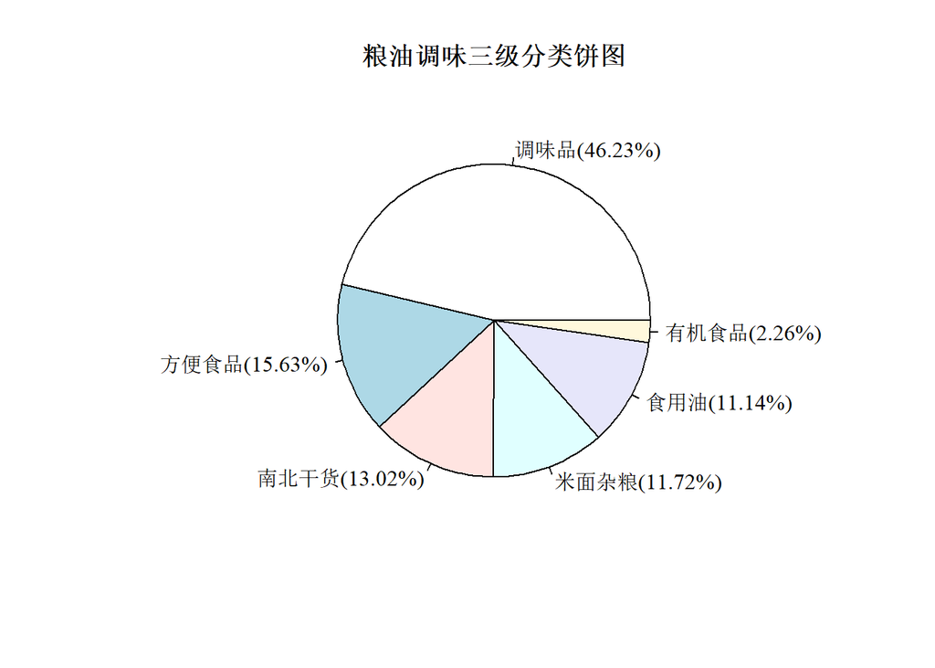

```r
library(plyr)
# 提取所需数据
my_data <- catalog[catalog$second == "粮油调味", ]

# 聚合数据
df <- ddply(my_data, .(third), nrow)

# help(ddply)
df <- df[order(df$V1, decreasing = TRUE),]

# 获取标签
label <- as.vector(df$third)
label <- paste(label, "(", round(df$V1/sum(df$V1)*100, 2), "%)", sep = "")

# 使用 R 自带的饼图函数
pie(df$V1, labels = label, main = "粮油调味三级分类饼图", family = "serif")
```

**解读:**

1. 调味品在 “粮油调味” 类别中占据了 $46.23\%$，是最大的分类  
   这表明调味品在消费者的日常烹饪中非常重要.  
   食用油的比重不及其 $1/4$，但仍具有一定市场.
2. 方便食品、南北干货和米面杂粮均具有一定的市场，其中方便食品较多.  
   反映了现代生活节奏加快，消费者对方便食品的需求较多.  
   有机食品只占据了 $2.26\%$

### (2) 分词处理

利用 `jiebaR` 包中的分词函数对商品名称进行分词处理.  
以二级分类 “粮油调味” 为例，用直方图展示该类别下商品的分词数量分布并生成词云图.  
并对结果进行解读.

```r
library(jiebaR)
library(NLP)
library(tm)

# 初始化分词工具 https://qinwenfeng.com/jiebaR/worker-.html
seg <- worker(bylines = T)

# 读入自定义词典
userdict <- read.table('userdict.dat', header = F, stringsAsFactors = F)

# 将词典加入分词引擎
new_user_word(seg, userdict$V1)
```

```
## [1] TRUE
```

```r
# 确保为字符类型
my_data$name <- as.character(my_data$name)
my_data$name <- tolower(my_data$name)  # 转为小写

# 分词
catalog_seg <- segment(my_data$name, seg)

# 文本预处理
my_data$name <- gsub("[0-9]", "", my_data$name)  # 去除数字
my_data$name <- gsub("[a-zA-Z]", "", my_data$name)  # 去除英文字符
my_data$name <- gsub("[[:punct:]]", "", my_data$name)  # 去除标点符号
my_data$name <- trimws(my_data$name)  # 去除多余的空格

# 分词
my_seg <- segment(my_data$name, seg)

# 自定义停用词
unit_stopwords <- c("g", "kg", "ml", "l", "袋", "瓶", "个", "件", "箱", "包", "克", "升", "毫升", "公斤", "斤", "分", "毫", "寸", "英寸", "平方", "立方", "打")
custom_stopwords <- c("的", "了", "是", "我", "在", "有", "和", "对", "就", "不", "人", "都", "一个", "也", "而", "该", "所", "上", "到", "说", "会", "这个", "那", "与", "为", "下", "很", "着", "把", "等")
stopwords <- unique(c(custom_stopwords, unit_stopwords))

# stopwords中可能存在一些包含在自定义词典中的专有名词，去掉
stopwords <- setdiff(stopwords, userdict)

# 去除停用词
my_seg <- lapply(my_seg, function(x) {
  x[!x %in% stopwords]
})
head(my_seg)
```

```
## [[1]]
##  [1] "麻辣"     "小"       "海鲜即食" "麻辣"     "八爪鱼"   "扇贝"
##  [7] "大虾"     "蚬子"     "鲍鱼"     "海螺"     "海鲜熟食" "即食"
## [13] "罐装"
##
## [[2]]
##  [1] "天地"   "粮人"   "有机"   "高粱米" "东北"   "粗粮"   "杂粮"   "粗粮"
##  [9] "大米"   "粥"     "米"     "伴侣"
##
## [[3]]
##  [1] "福来"   "康泰"   "有机"   "黄金"   "亚麻籽" "粉熟"   "亚麻子" "粉"
##  [9] "胡麻"   "籽粉"   "即食"   "炒货"   "开罐"   "即食"
##
## [[4]]
## [1] "得尔乐" "有机"   "山茶油" "礼盒"   "茶籽油" "食用油" "压榨"   "一级"
##
## [[5]]
##  [1] "天地"     "粮人"     "有机"     "豆浆"     "豆"       "黄豆"
##  [7] "红小豆"   "绿豆"     "黑豆"     "红皮花生"
##
## [[6]]
##  [1] "天地" "粮人" "有机" "绿豆" "可发" "豆芽" "豆浆" "东北" "粗粮" "杂粮"
## [11] "大米" "伴侣"
```

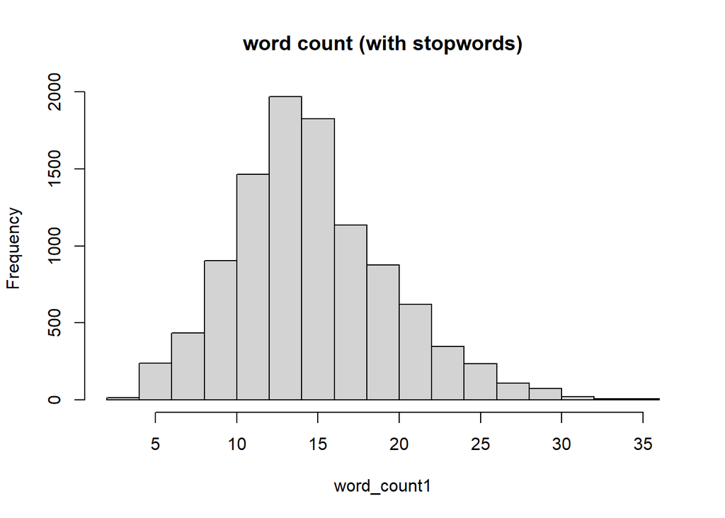

```r
# 统计商品名称包含的词数
word_count1 <- sapply(catalog_seg, length)

# 绘制直方图
hist(word_count1, main = "word count (with stopwords)")
```

```r
library(wordcloud2)
# wordcloud2 包使用 install.packages() 安装会出现问题，应当这样安装:
# install.packages('devtools')
# devtools::install_github("lchiffon/wordcloud2")

# 建立数据框
catalog_seg_df = data.frame(table(unlist(catalog_seg)))

# 对词频进行降序排列，找到高频词
catalog_seg_df = catalog_seg_df[order(catalog_seg_df$Freq, decreasing = T),]

# 构建词云图
wordcloud2(catalog_seg_df[1:50,])
```

[interactive chart not shown]

**解读:**

1. 包装和单位相关词 `g`、`袋`、`ml` 出现频次很高，但通常不对分类有实质性贡献  
   我们应当忽略这些特征词，否则可能会引入噪声，而不能增强模型的分类能力.
2. 以下是一些应当关注的特征词:  
   `调料`、`调味料`、`食用油`、`特产` 和 `麻辣`  
   它们提供了关于商品类型、风味、使用方式等有价值的信息，是帮助模型识别不同类别的关键.

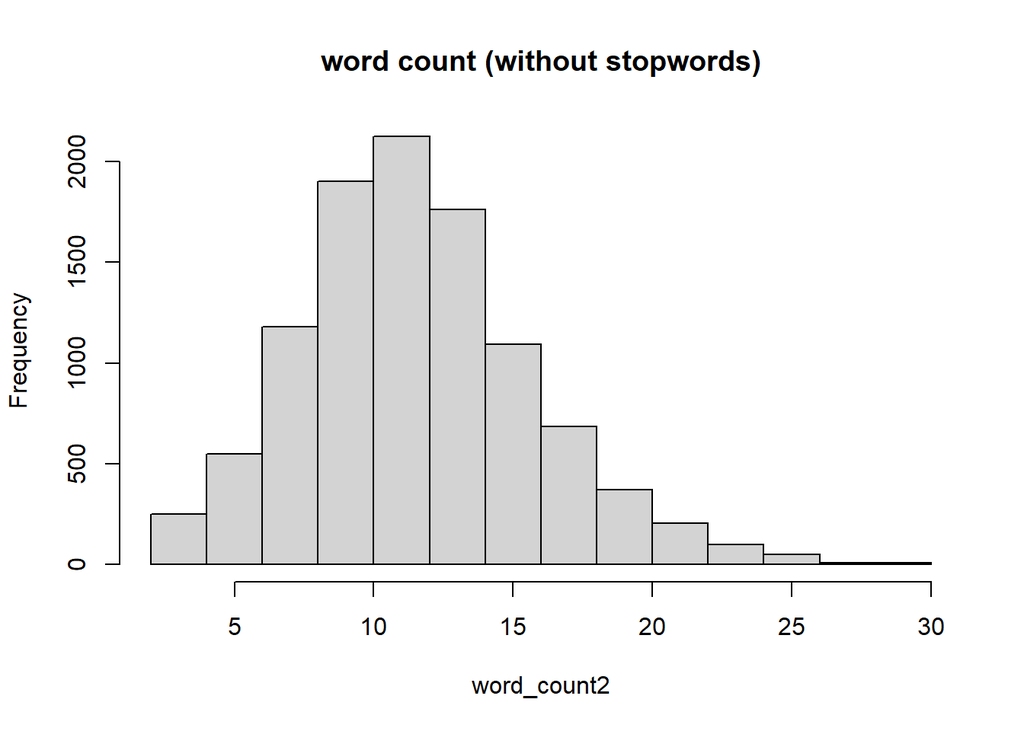

```r
# 统计商品名称包含的词数
word_count2 <- sapply(my_seg, length)

# 绘制直方图
hist(word_count2, main = "word count (without stopwords)")
```

```r
# 建立数据框
my_seg_df = data.frame(table(unlist(my_seg)))

# 对词频进行降序排列，找到高频词
my_seg_df = my_seg_df[order(my_seg_df$Freq, decreasing = T),]

# 构建词云图
wordcloud2(my_seg_df[1:50,], size = 0.3)
```

[interactive chart not shown]

### (3) 朴素 Bayes 分类

对文本进行分词处理，建立文档词频矩阵.  
将二级分类为“粮油调味”的数据按 7:3 的比例划分为训练集和测试集.  
以文档词频矩阵为自变量，以每个商品名称对应的三级分类为因变量，  
对训练集建立朴素贝叶斯分类器，使用建立的分类器对测试集中的商品进行预测，  
并计算测试集上的预测准确率.

```r
library(text2vec)

# 设置随机种子以确保结果可复现
set.seed(51)

# 划分训练集和测试集
train_index <- sample(1:nrow(my_data), 0.7 * nrow(my_data))
train_data <- my_data[train_index, ]
test_data <- my_data[-train_index, ]

head(train_data)
```

|  | name | first | second | third |
| --- | --- | --- | --- | --- |
| 29985 | 西班牙原瓶原装进口 特迷尔特级初榨橄榄油 玻璃瓶 孕妇婴儿辅食食用油 | 食品饮料、保健食品 | 粮油调味 | 食用油 |
| 35534 | 天地粮人 东北大米 珍珠米 | 食品饮料、保健食品 | 粮油调味 | 米面杂粮 |
| 46718 | 熊猫 炼乳原味 早餐伴侣炼奶蛋挞甜点烘培原料 | 食品饮料、保健食品 | 粮油调味 | 调味品 |
| 28373 | 中粮我买网海天 陈醋 | 食品饮料、保健食品 | 粮油调味 | 调味品 |
| 69163 | 贵州特产遵义烧烤辣椒面五香蘸水烙锅麻辣炸土豆辣椒面 | 食品饮料、保健食品 | 粮油调味 | 调味品 |
| 55384 | 官方直营外婆卤老卤汁卤水卤鸡爪鸡翅猪肉羊地道潮汕味卤肉卤水料香浓调料包包邮 辣香味包 | 食品饮料、保健食品 | 粮油调味 | 调味品 |

```r
head(test_data)
```

|  | name | first | second | third |
| --- | --- | --- | --- | --- |
| 28283 | 麻辣小海鲜即食麻辣八爪鱼扇贝大虾蚬子鲍鱼海螺海鲜熟食即食罐装 | 食品饮料、保健食品 | 粮油调味 | 有机食品 |
| 28285 | 福来康泰有机黄金亚麻籽粉熟亚麻子粉胡麻籽粉即食炒货开罐即食 | 食品饮料、保健食品 | 粮油调味 | 有机食品 |
| 28291 | 桂花香精 食用液体饮料花香烘焙食品添加剂钓鱼小药 水油两用香精 草莓香精 | 食品饮料、保健食品 | 粮油调味 | 有机食品 |
| 28296 | 新疆和田大枣 四星级玉枣 二级骏枣袋 | 食品饮料、保健食品 | 粮油调味 | 有机食品 |
| 28301 | 重庆酸辣粉农家手工纯红薯粉条地瓜粉红苕粉条火锅粗粉条 | 食品饮料、保健食品 | 粮油调味 | 有机食品 |
| 28302 | 天地粮人 有机 黄豆可发豆芽 打豆浆 大豆 粗粮杂粮 大米伴侣 | 食品饮料、保健食品 | 粮油调味 | 有机食品 |

```r
# 分词结果相应进行拆分
seg_train <- my_seg[train_index]
seg_test <- my_seg[-train_index]
```

```r
# 设置分词迭代器
iter_train <- itoken(seg_train, ids = train_data$id)
iter_test <- itoken(seg_test, ids = test_data$id)

# 修剪低频词、高频词
vocab <- create_vocabulary(iter_train)
vocab <- prune_vocabulary(vocab, doc_count_min = 10, doc_proportion_max = 0.75)

# 保留词频前1000的词语
vocab <- vocab[order(vocab$term_count, decreasing = TRUE), ]
vocab <- vocab[1:1000, ]

# 初步形成语料文件
vectorizer <- vocab_vectorizer(vocab)

# 根据语料文件生成文档-词频矩阵
dtm_train <- as.matrix(create_dtm(iter_train, vectorizer))
dtm_test <- as.matrix(create_dtm(iter_test, vectorizer))

# 转化为0-1矩阵
dtm_train[dtm_train > 1] <- 1
dtm_test[dtm_test > 1] <- 1
dtm_train <- apply(dtm_train, 2, as.factor)
dtm_test <- apply(dtm_test, 2, as.factor)

# 检查维度
dim(dtm_train)
```

```
## [1] 7201 1000
```

```r
dim(dtm_test)
```

```
## [1] 3087 1000
```

```r
library(e1071)

# 训练朴素贝叶斯分类器
naiveBayes_model <- naiveBayes(x = dtm_train, y = as.factor(train_data$third), laplace = 0)

# 查看模型
summary(naiveBayes_model)
```

```
##           Length Class  Mode
## apriori      6   table  numeric
## tables    1000   -none- list
## levels       6   -none- character
## isnumeric 1000   -none- logical
## call         4   -none- call
```

```r
# 进行预测
predictions <- predict(naiveBayes_model, dtm_test, type = 'class')

# 计算准确率
accuracy <- sum(as.character(test_data$third) == as.character(predictions)) / nrow(test_data)
accuracy
```

```
## [1] 0.9167477
```